# Creating ignition maps for SCRPPLE

Sam Flake

8/17/2021

## Create ignitions maps for SCRPPLE

## From Short et al. data and a boundary box of the study area

```r
library("raster")
library("sf")
library("sp")
library("spatstat")
```

Set the working directory

```r
setwd("C:/Users/Sam/Documents/Research/California forest economics")
```

# raster to get bounding box from

```r
mask <- raster("./masks_boundaries/mask.tif")
crs(mask) <- "EPSG:2163"
```

What does the mask look like?

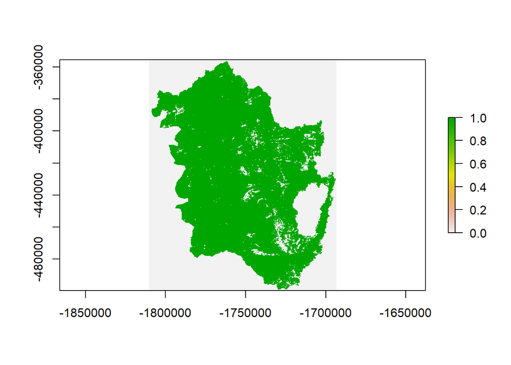

```r
plot(mask)
```

#——————————————————————————- #import Short data This takes a little bit to load – it’s a big dataset!

```r
sf::st_layers("./calibration data/short/Data/FPA_FOD_20210617.gdb")
```

```
## Driver: OpenFileGDB
## Available layers:
##                   layer_name geometry_type features fields
## 1                      Fires         Point  2166753     37
## 2 NWCG_UnitIdActive_20200123            NA     5971     12
```

```r
short <- sf::st_read("./calibration data/short/Data/FPA_FOD_20210617.gdb", layer = "Fires")
st_geometry_type(short)
```

[output not shown]

[output cut: 8321 more lines]

```r
st_crs(short)
```

```
## Coordinate Reference System:
##   User input: NAD83
##   wkt:
## GEOGCRS["NAD83",
##     DATUM["North American Datum 1983",
##         ELLIPSOID["GRS 1980",6378137,298.257222101,
##             LENGTHUNIT["metre",1]]],
##     PRIMEM["Greenwich",0,
##         ANGLEUNIT["degree",0.0174532925199433]],
##     CS[ellipsoidal,2],
##         AXIS["geodetic latitude (Lat)",north,
##             ORDER[1],
##             ANGLEUNIT["degree",0.0174532925199433]],
##         AXIS["geodetic longitude (Lon)",east,
##             ORDER[2],
##             ANGLEUNIT["degree",0.0174532925199433]],
##     USAGE[
##         SCOPE["unknown"],
##         AREA["North America - NAD83"],
##         BBOX[14.92,167.65,86.46,-47.74]],
##     ID["EPSG",4269]]
```

```r
short <- st_transform(short, 2163)
```

#make a bounding box for Short data bound <- extent(mask) bound[c(1,3)] <- bound[c(1,3)] - 30000 bound[c(2,4)] <- bound[c(2,4)] + 30000

bound <- as(bound, ‘SpatialPolygons’) %>% st_as_sf() %>% st_set_crs(2163)

short_subset <- sf::st_intersection(short, bound)

lightning_ignitions <- short_subset[short_subset$NWCG_CAUSE_CLASSIFICATION == “Natural”, ] head(lightning_ignitions) nrow(lightning_ignitions) #6100 – pretty good sample!

acc_ignitions <- short_subset[short_subset$NWCG_CAUSE_CLASSIFICATION == “Human”, ] head(acc_ignitions) nrow(acc_ignitions) #27232 – that’s a ton!

#——————————————————————————- # Do a density kernel to estimate intensity # these are made oversized to avoid edge effects, and then lateraligned and # clipped to the mask of the study area

lightning_coords <- as.data.frame(st_coordinates(lightning_ignitions)) win <- owin(xrange = range(lightning_coords$X), yrange = range(lightning_coords$Y)) lightning.ppp <- ppp(lightning_coords$X, lightning_coords$Y, window = win) lightning_raster <- spatstat::density.ppp(lightning.ppp, adjust = 0.2, kernel = “gaussian”, eps = 180) plot(lightning_raster) hist(lightning_raster) lightning_raster <- lightning_raster * 1e7 # writeRaster(raster(lightning_raster), “lightning_ignitions.tiff”, “GTiff”, overwrite = TRUE)

acc_coords <- as.data.frame(st_coordinates(acc_ignitions)) win <- owin(xrange = range(acc_coords$X), yrange = range(acc_coords$Y)) acc.ppp <- ppp(acc_coords$X, acc_coords$Y, window = win) acc_raster <- spatstat::density.ppp(acc.ppp, adjust = 0.2, kernel = “gaussian”, eps = 180) plot(acc_raster) hist(acc_raster) acc_raster <- acc_raster * 1e6 # writeRaster(raster(acc_raster), “acc_ignitions.tiff”, “GTiff”, overwrite = TRUE)

#clip the new rasters to mask mask <- raster(“./masks_boundaries/mask.tif”) crs(mask) <- “EPSG:2163”

lightning_raster <- raster(lightning_raster) lightning_clip <- raster::crop(lightning_raster, extent(mask)) lightning_clip <- raster::resample(lightning_raster, mask, method = “bilinear”) lightning_masked <- raster::mask(lightning_clip, mask, maskvalue = 0, updatevalue = 0) writeRaster(lightning_masked, “./input_rasters_tcsi/lightning_tcsi.tif”, “GTiff”, overwrite = TRUE)

acc_raster <- raster(acc_raster) acc_clip <- raster::crop(acc_raster, extent(mask)) acc_clip <- raster::resample(acc_raster, mask, method = “bilinear”) acc_masked <- raster::mask(acc_clip, mask, maskvalue = 0, updatevalue = 0) writeRaster(acc_masked, “./input_rasters_tcsi/accidental_tcsi.tif”, “GTiff”, overwrite = TRUE)